# Analisis Acelga Fecha 1

Franco Villalba

2024-02-12

# Descripcion

# Analisis Variables del 06 de Diciembre del 2022

### Importar la base de datos:

```r
MS06DIC<-read.csv("MS06DIC.csv", header=TRUE, sep=",", dec=",")
MS06DIC["Tratamientos"]<-paste(MS06DIC$NombreV, MS06DIC$Dosis, sep="_") #esto agrega una columna con el nombre del tratamiento

MS06DIC
```

| Bloque | Dosis | Variedad | Pesos_hojas | Peso_Raiz | Razon_RPA | Pn | GrM2 | NombreV | PesoT | A | PTM2 | Tratamientos |
| --- | --- | --- | --- | --- | --- | --- | --- | --- | --- | --- | --- | --- |
| 1 | 1 | 1 | 0.24 | 0.06 | 4.000000 | 0.0 | 0 | Penca Ancha | 0.30 | 39.216 | 1.600000 | Penca Ancha_1 |
| 1 | 2 | 1 | 0.51 | 0.08 | 6.375000 | 0.5 | 427 | Penca Ancha | 0.59 | 122.487 | 3.146667 | Penca Ancha_2 |
| 1 | 3 | 1 | 0.40 | 0.07 | 5.714286 | 1.0 | 854 | Penca Ancha | 0.47 | 80.246 | 2.506667 | Penca Ancha_3 |
| 1 | 4 | 1 | 0.69 | 0.05 | 13.800000 | 1.5 | 1282 | Penca Ancha | 0.74 | 147.952 | 3.946667 | Penca Ancha_4 |
| 1 | 1 | 2 | 0.18 | 0.04 | 4.500000 | 0.0 | 0 | Penca Verde | 0.22 | 51.222 | 1.173333 | Penca Verde_1 |
| 1 | 2 | 2 | 0.62 | 0.04 | 15.500000 | 0.5 | 427 | Penca Verde | 0.66 | 151.354 | 3.520000 | Penca Verde_2 |
| 1 | 3 | 2 | 0.70 | 0.06 | 11.666667 | 1.0 | 854 | Penca Verde | 0.76 | 162.193 | 4.053333 | Penca Verde_3 |
| 1 | 4 | 2 | 0.41 | 0.05 | 8.200000 | 1.5 | 1282 | Penca Verde | 0.46 | 93.705 | 2.453333 | Penca Verde_4 |
| 2 | 1 | 1 | 1.46 | 0.17 | 8.588235 | 0.0 | 0 | Penca Ancha | 1.63 | 317.397 | 8.693333 | Penca Ancha_1 |
| 2 | 2 | 1 | 0.83 | 0.11 | 7.545455 | 0.5 | 427 | Penca Ancha | 0.94 | 186.780 | 5.013333 | Penca Ancha_2 |

[output cut: 22 more lines]

## Analisis variable: Peso de raiz

#### Estadistica descriptiva de la variable

Primero crearemos una funcion que nos permite crear un dataframe con cada tratamiento, agregando el nro de observaciones, la media, el desvio standar y el CV

```r
resumir2fat<-function(fat1,
                      fat2,
                      resp,
                      trat,
                      df
){
  nf1<-unique(fat1)
  nf2<-unique(fat2)
  alltrat<-unique(trat)

  medias<-c()
  Desvio_Standar<-c()
  numero<-c()

  for (f1 in nf1){
    medias<-c(medias, mean(resp[fat1==f1]))
    Desvio_Standar<-c(Desvio_Standar, sd(resp[fat1==f1]))
    numero<-c(numero, sum(with(df, fat1==f1)))
  }

  for (f2 in nf2){
    medias<-c(medias, mean(resp[fat2==f2]))
    Desvio_Standar<-c(Desvio_Standar, sd(resp[fat2==f2]))
    numero<-c(numero, sum(with(df, fat2==f2)))
  }
  for (t in alltrat){
    medias<-c(medias, mean(resp[trat==t]))
    Desvio_Standar<-c(Desvio_Standar, sd(resp[trat==t]))
    numero<-c(numero, sum(with(df, trat==t)))
  }
  agrupamientos<-c(nf1, nf2, alltrat)
  CV<-(Desvio_Standar/medias)*100
  return(data.frame(agrupamientos, numero, medias, Desvio_Standar, CV))
}
```

Luego llamaremos a la funcion, guardaremos el resultado en una variable:

```r
descPR06DIC<-resumir2fat(MS06DIC$Dosis, MS06DIC$NombreV, MS06DIC$Peso_Raiz, MS06DIC$Tratamientos, MS06DIC)
descPR06DIC
```

| agrupamientos | numero | medias | Desvio_Standar | CV |
| --- | --- | --- | --- | --- |
| 1 | 8 | 0.08875 | 0.05642631 | 63.57894 |
| 2 | 8 | 0.08250 | 0.05284749 | 64.05756 |
| 3 | 8 | 0.08625 | 0.04501984 | 52.19691 |
| 4 | 8 | 0.06000 | 0.02203893 | 36.73154 |
| Penca Ancha | 16 | 0.07625 | 0.03242941 | 42.53037 |
| Penca Verde | 16 | 0.08250 | 0.05627314 | 68.20987 |
| Penca Ancha_1 | 4 | 0.09250 | 0.05188127 | 56.08786 |
| Penca Ancha_2 | 4 | 0.07750 | 0.02500000 | 32.25806 |
| Penca Ancha_3 | 4 | 0.07250 | 0.03304038 | 45.57294 |
| Penca Ancha_4 | 4 | 0.06250 | 0.01500000 | 24.00000 |

[output cut: 4 more lines]

#### Análisis exploratorio gráfico

Utilizaremos Box plot

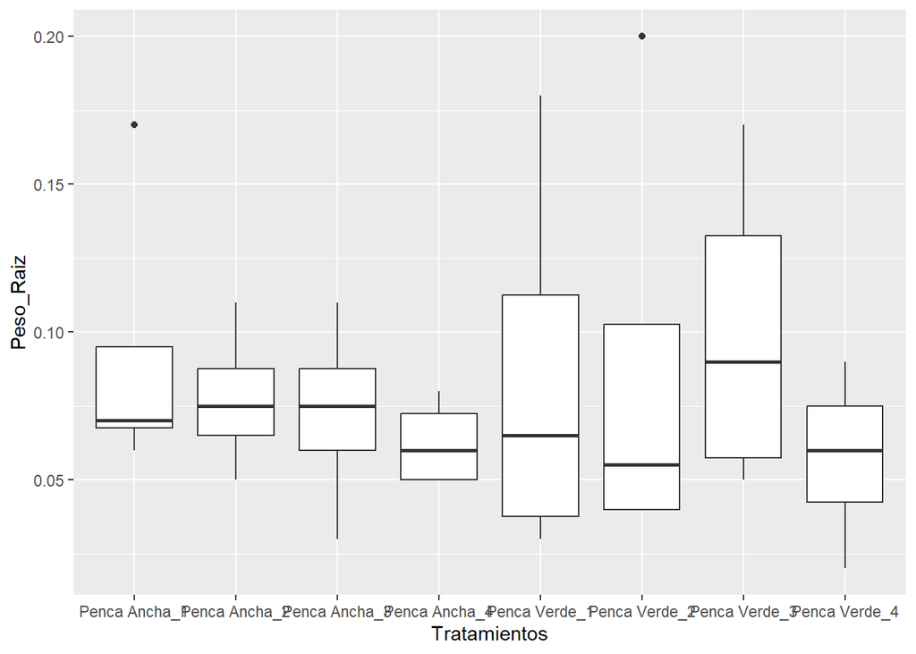

```r
library(ggplot2) #Iniciamos la libreria, si lo hacemos por primera vez, antes debemos instalas con install.packages("ggplot2")


ggplot(data=MS06DIC, aes(Tratamientos, Peso_Raiz))+geom_boxplot() ###Un boxplot con todos los tratamientos
```

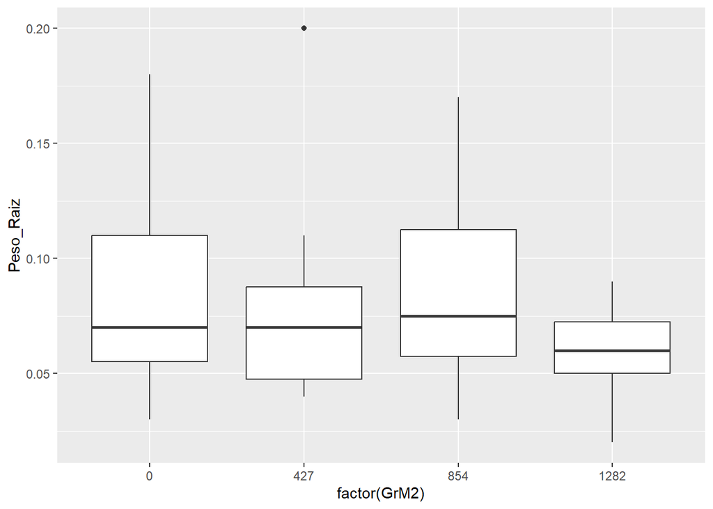

```r
ggplot(data=MS06DIC, aes(factor(GrM2), Peso_Raiz))+geom_boxplot() ###Un boxplot considerando solo el factor Abono
```

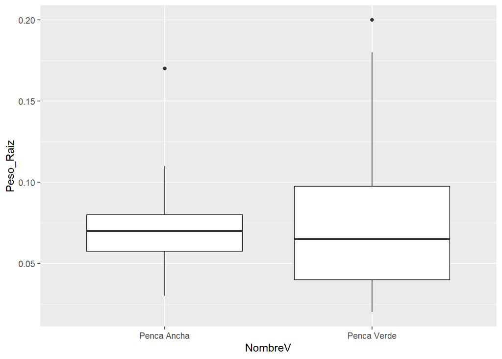

```r
ggplot(data=MS06DIC, aes(NombreV, Peso_Raiz))+geom_boxplot() ###Un boxplot considerando solo el factor cultivar
```

#### Analisis de outliers

A partir de los gráficos podemos detectar algunos outliers, para detectarlos podemos utilizar la función plot ingresando una formula con el modelo.

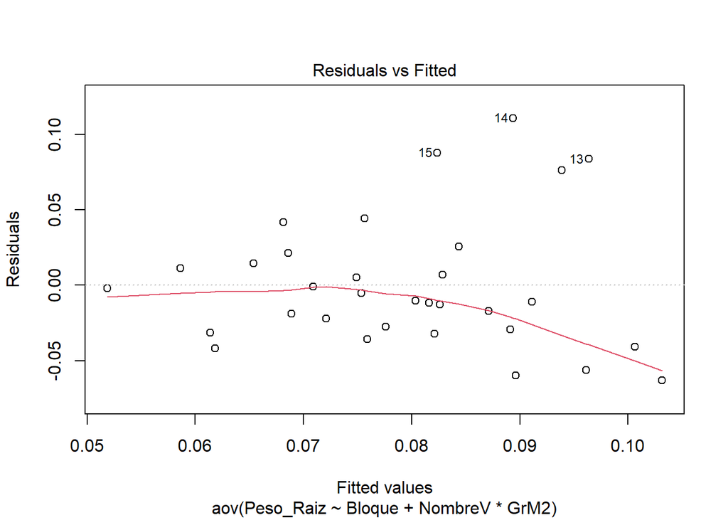

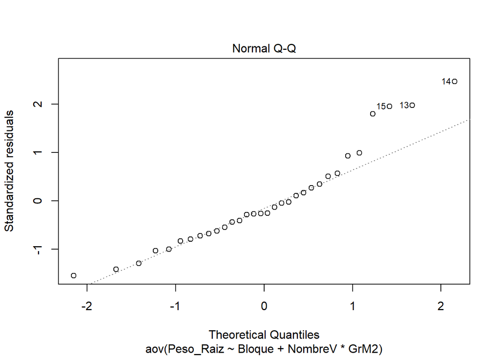

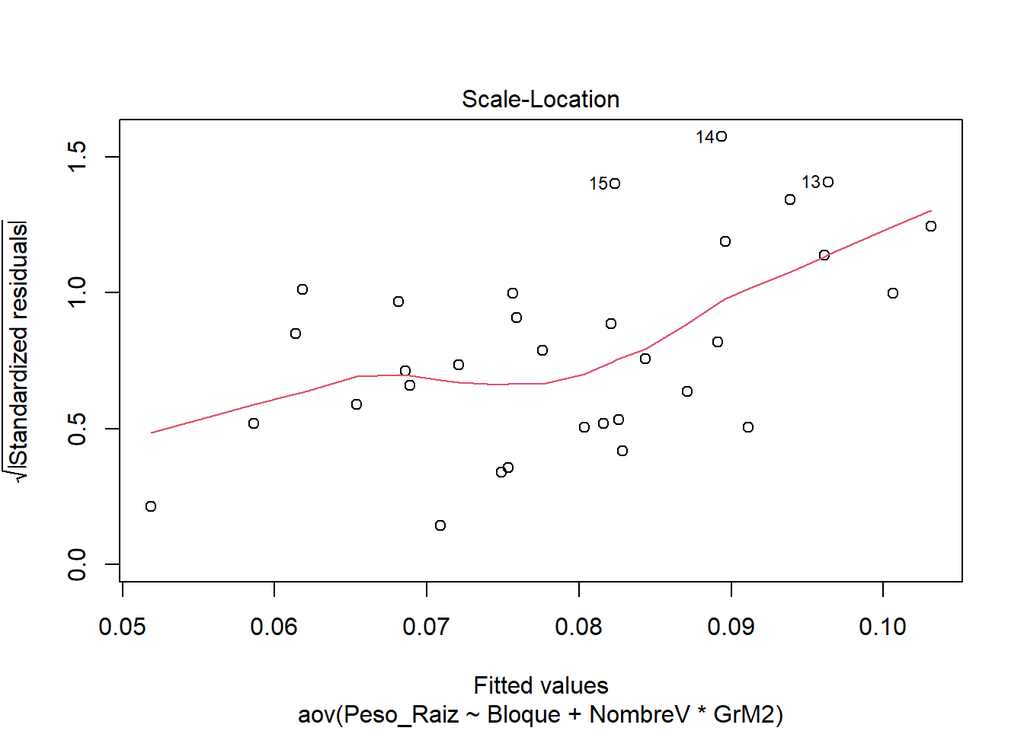

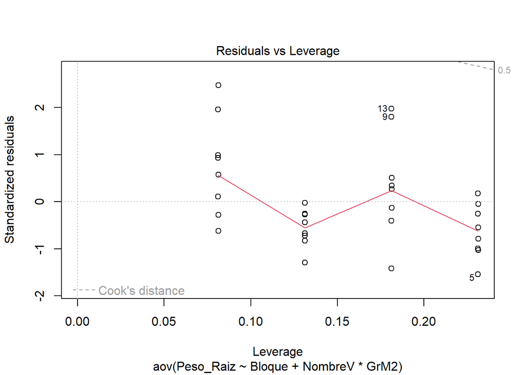

```r
plot(aov(Peso_Raiz~Bloque+NombreV*GrM2, MS06DIC))
```

#### Analisis de la varianza en DCB Bifactorial

Realizaremos un análisis sin reemplazar outliers, para esto utilizamos el paquete ExpDes.pt

```r
library(ExpDes.pt)

fat2.dbc( MS06DIC$GrM2,
          MS06DIC$NombreV,
          MS06DIC$Bloque,
          MS06DIC$Peso_Raiz,
          quali= c(FALSE, TRUE),
          mcomp="tukey",
          fac.names=c("Gramos Abono por m2", "Variedad")
)
```

```
## ------------------------------------------------------------------------
## Legenda:
## FATOR 1:  Gramos Abono por m2
## FATOR 2:  Variedad
## ------------------------------------------------------------------------
##
##
## Quadro da analise de variancia
## ------------------------------------------------------------------------
##                              GL       SQ QM     Fc   Pr>Fc
## Bloco                         3 0.032712  6 9.2194 0.00043
## Gramos Abono por m2           3 0.004163  5 1.1731 0.34366
## Variedad                      1 0.000312  2 0.2642 0.61260
## Gramos Abono por m2*Variedad  3 0.001562  3 0.4404 0.72653
## Residuo                      21 0.024838  4
## Total                        31 0.063587  1
## ------------------------------------------------------------------------
## CV = 43.33 %
##
## ------------------------------------------------------------------------
## Teste de normalidade dos residuos (Shapiro-Wilk)
## valor-p:  0.3679399
## De acordo com o teste de Shapiro-Wilk a 5% de significancia, os residuos podem ser considerados normais.
## ------------------------------------------------------------------------
##
## Interacao nao significativa: analisando os efeitos simples
## ------------------------------------------------------------------------
## Gramos Abono por m2
## De acordo com o teste F, as medias desse fator sao estatisticamente iguais.
##
## ------------------------------------------------------------------------
##   Niveis  Medias
## 1      0 0.08875
## 2   1282 0.06000
## 3    427 0.08250
## 4    854 0.08625
## ------------------------------------------------------------------------
## Variedad
## De acordo com o teste F, as medias desse fator sao estatisticamente iguais.
## ------------------------------------------------------------------------
##        Niveis  Medias
## 1 Penca Ancha 0.07625
## 2 Penca Verde 0.08250
## ------------------------------------------------------------------------
```

#### Observaciones Preliminares

Si bien los test no identificaron diferencias significativas las medias de la dosis de abono 4 fue menor en todos los casos, puedo que la planta por tener mayor contenido de nutrientes haya derivado menores cantidades de fotoasimilados a la raiz.

### Analisis de Variable: Peso de MS de parte aérea

#### Estadisitica descriptiva de la variable

```r
DescPAMS06DIC<-resumir2fat(MS06DIC$Dosis, MS06DIC$NombreV, MS06DIC$Pesos_hojas, MS06DIC$Tratamientos, MS06DIC)
DescPAMS06DIC
```

| agrupamientos | numero | medias | Desvio_Standar | CV |
| --- | --- | --- | --- | --- |
| 1 | 8 | 0.711250 | 0.5065411 | 71.21844 |
| 2 | 8 | 0.797500 | 0.3996338 | 50.11082 |
| 3 | 8 | 0.855000 | 0.4297840 | 50.26713 |
| 4 | 8 | 0.672500 | 0.3054622 | 45.42189 |
| Penca Ancha | 16 | 0.716875 | 0.3196606 | 44.59085 |
| Penca Verde | 16 | 0.801250 | 0.4784820 | 59.71694 |
| Penca Ancha_1 | 4 | 0.707500 | 0.5258247 | 74.32152 |
| Penca Ancha_2 | 4 | 0.777500 | 0.1839157 | 23.65476 |
| Penca Ancha_3 | 4 | 0.585000 | 0.3075169 | 52.56700 |
| Penca Ancha_4 | 4 | 0.797500 | 0.2629797 | 32.97551 |

[output cut: 4 more lines]

#### Gráficos BoxPlot

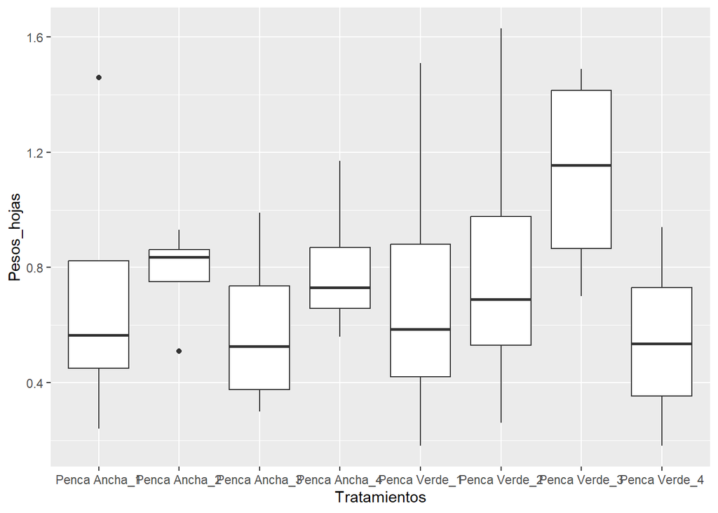

```r
ggplot(data=MS06DIC, aes(Tratamientos, Pesos_hojas))+geom_boxplot() ###Un boxplot con todos los tratamientos
```

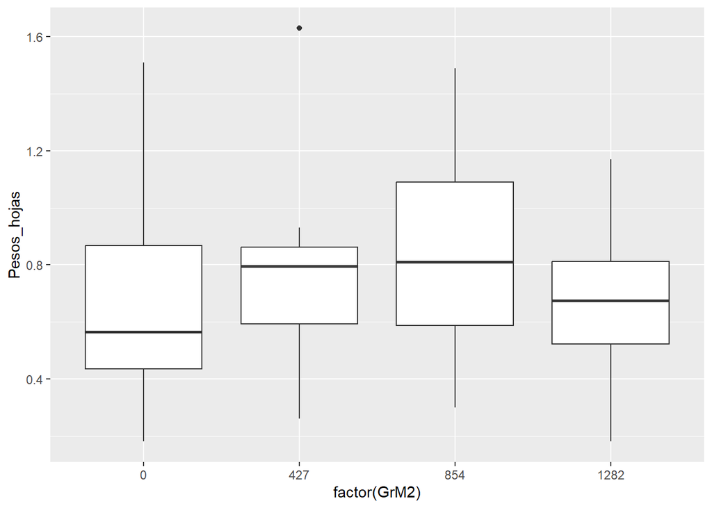

```r
ggplot(data=MS06DIC, aes(factor(GrM2), Pesos_hojas))+geom_boxplot() ###Un boxplot considerando solo el factor Abono
```

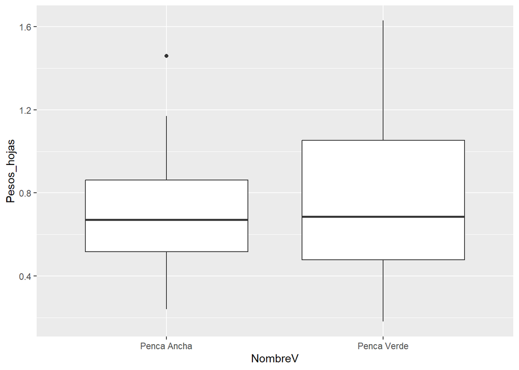

```r
ggplot(data=MS06DIC, aes(NombreV, Pesos_hojas))+geom_boxplot() ###Un boxplot considerando solo el factor cultivar
```

#### Deteccion Outliers

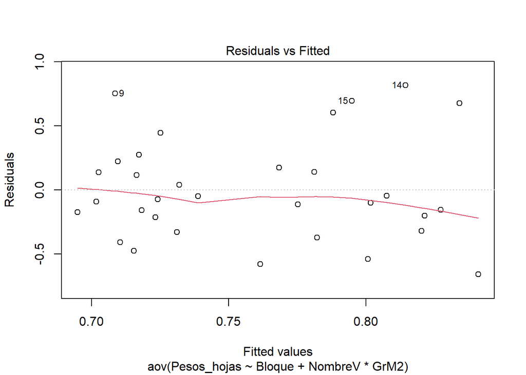

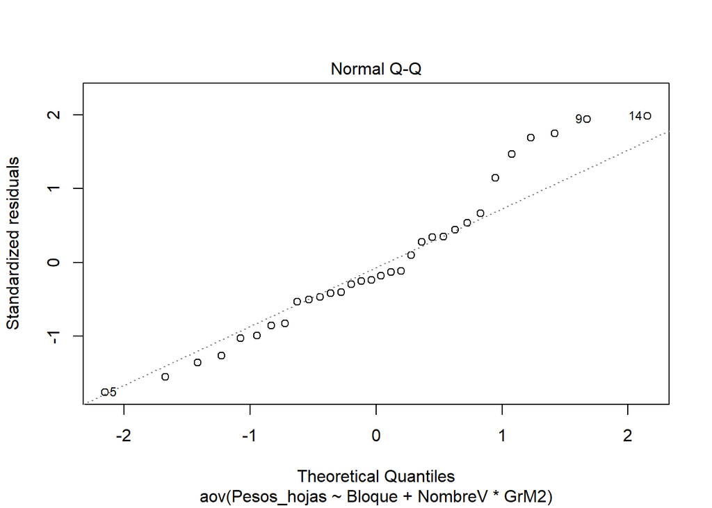

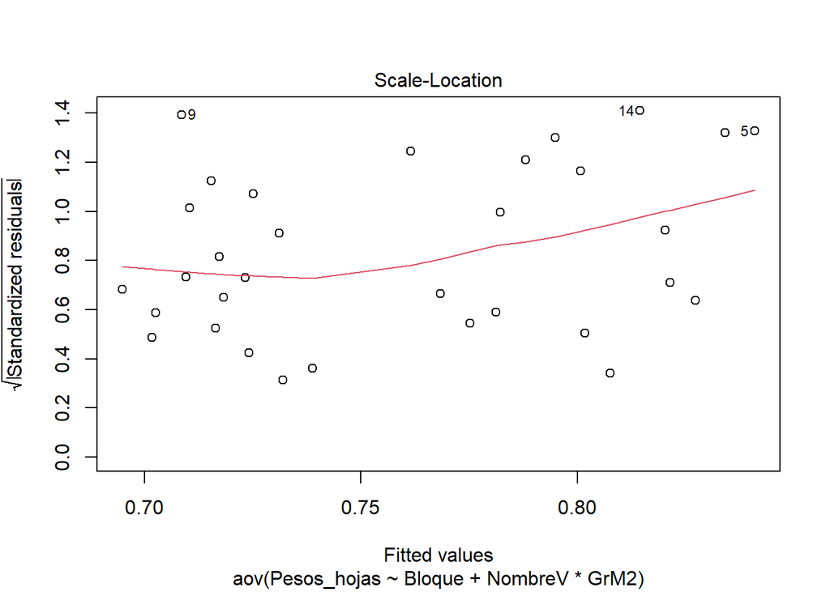

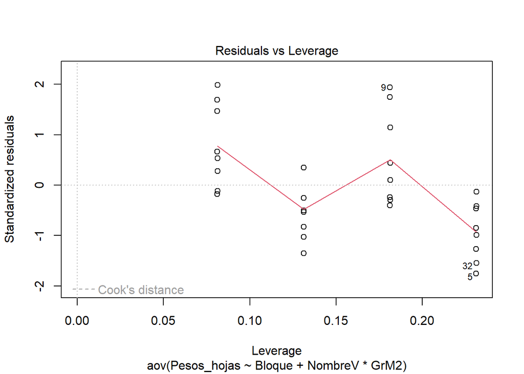

```r
    plot(aov(Pesos_hojas~Bloque+NombreV*GrM2, MS06DIC))
```

En base al grafico Normal Q-Q plot, se detectan las observaciones 9, 14 y 5 como posibles outliers. Esto corresponden al bloque 2, dosis 1, variedad 1, bloque 2 dosis 2 variedad 2 (estos con valores por encima de la media) y al bloque 1, dosis 1, variedad 2.

#### Analisis de la Varianza en DBC

```r
library(ExpDes.pt)

fat2.dbc( MS06DIC$GrM2,
          MS06DIC$NombreV,
          MS06DIC$Bloque,
          MS06DIC$Pesos_hojas,
          quali= c(FALSE, TRUE),
          mcomp="tukey",
          fac.names=c("Gramos Abono por m2", "Variedad")
)
```

```
## ------------------------------------------------------------------------
## Legenda:
## FATOR 1:  Gramos Abono por m2
## FATOR 2:  Variedad
## ------------------------------------------------------------------------
##
##
## Quadro da analise de variancia
## ------------------------------------------------------------------------
##                              GL     SQ QM      Fc   Pr>Fc
## Bloco                         3 2.4824  6 10.4289 0.00021
## Gramos Abono por m2           3 0.1637  2  0.6877 0.56963
## Variedad                      1 0.0570  3  0.7178 0.40642
## Gramos Abono por m2*Variedad  3 0.6546  5  2.7499 0.06829
## Residuo                      21 1.6662  4
## Total                        31 5.0239  1
## ------------------------------------------------------------------------
## CV = 37.11 %
##
## ------------------------------------------------------------------------
## Teste de normalidade dos residuos (Shapiro-Wilk)
## valor-p:  0.3383185
## De acordo com o teste de Shapiro-Wilk a 5% de significancia, os residuos podem ser considerados normais.
## ------------------------------------------------------------------------
##
## Interacao nao significativa: analisando os efeitos simples
## ------------------------------------------------------------------------
## Gramos Abono por m2
## De acordo com o teste F, as medias desse fator sao estatisticamente iguais.
##
## ------------------------------------------------------------------------
##   Niveis  Medias
## 1      0 0.71125
## 2   1282 0.67250
## 3    427 0.79750
## 4    854 0.85500
## ------------------------------------------------------------------------
## Variedad
## De acordo com o teste F, as medias desse fator sao estatisticamente iguais.
## ------------------------------------------------------------------------
##        Niveis   Medias
## 1 Penca Ancha 0.716875
## 2 Penca Verde 0.801250
## ------------------------------------------------------------------------
```

### Peso Total

Primero creamos la variable Peso total:

```r
MS06DIC$ptotal<-MS06DIC$Peso_Raiz + MS06DIC$Pesos_hojas
```

Luego realizamos el analisis estadistico descriptivo

```r
descPt06DIC<-resumir2fat(MS06DIC$Dosis, MS06DIC$NombreV, MS06DIC$ptotal, MS06DIC$Tratamientos, MS06DIC)
descPt06DIC
```

| agrupamientos | numero | medias | Desvio_Standar | CV |
| --- | --- | --- | --- | --- |
| 1 | 8 | 0.800000 | 0.5580579 | 69.75723 |
| 2 | 8 | 0.880000 | 0.4453570 | 50.60875 |
| 3 | 8 | 0.941250 | 0.4689331 | 49.82025 |
| 4 | 8 | 0.732500 | 0.3235407 | 44.16938 |
| Penca Ancha | 16 | 0.793125 | 0.3430592 | 43.25411 |
| Penca Verde | 16 | 0.883750 | 0.5297405 | 59.94235 |
| Penca Ancha_1 | 4 | 0.800000 | 0.5765992 | 72.07490 |
| Penca Ancha_2 | 4 | 0.855000 | 0.1789786 | 20.93317 |
| Penca Ancha_3 | 4 | 0.657500 | 0.3383662 | 51.46254 |
| Penca Ancha_4 | 4 | 0.860000 | 0.2716616 | 31.58855 |

[output cut: 4 more lines]

Analisis gráfico de la variable

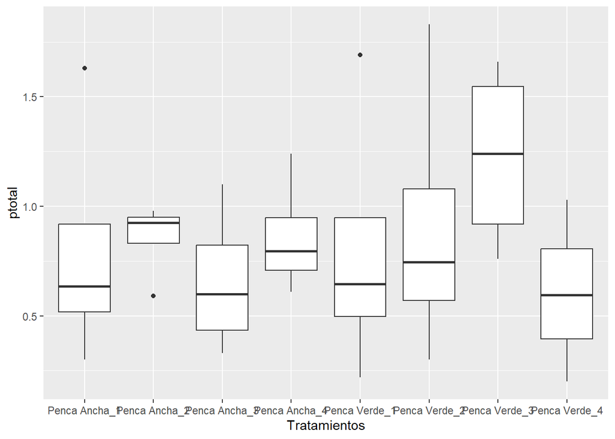

```r
ggplot(data=MS06DIC, aes(Tratamientos, ptotal))+geom_boxplot() ###Un boxplot con todos los tratamientos
```

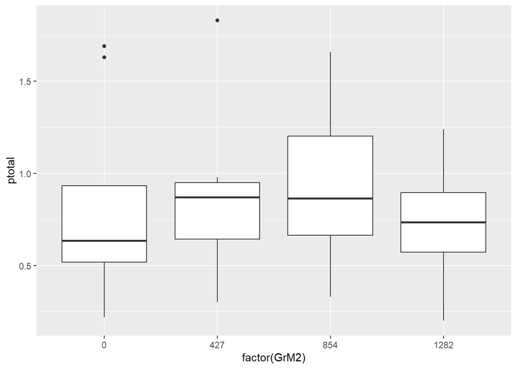

```r
ggplot(data=MS06DIC, aes(factor(GrM2), ptotal))+geom_boxplot() ###Un boxplot considerando solo el factor Abono
```

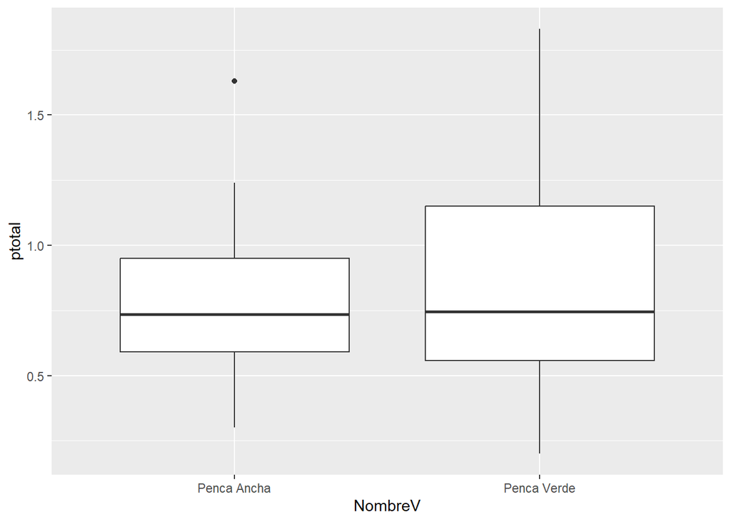

```r
ggplot(data=MS06DIC, aes(NombreV, ptotal))+geom_boxplot() ###Un boxplot considerando solo el factor cultivar
```

Analisis de outlier

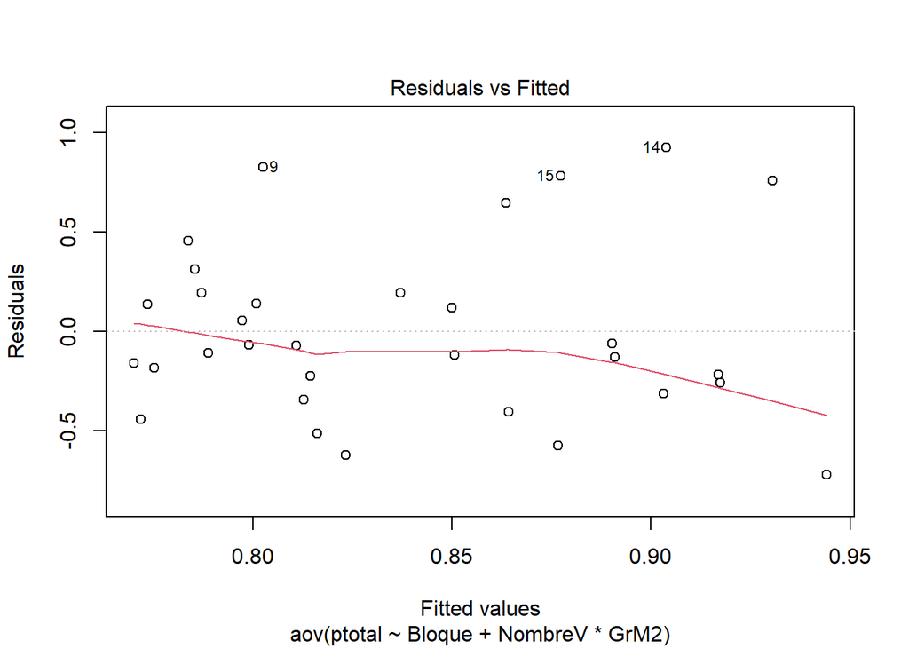

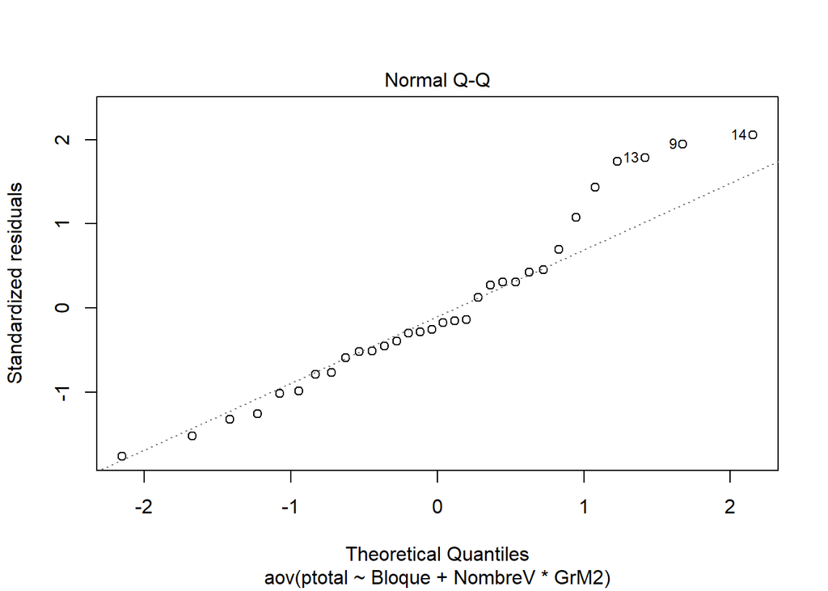

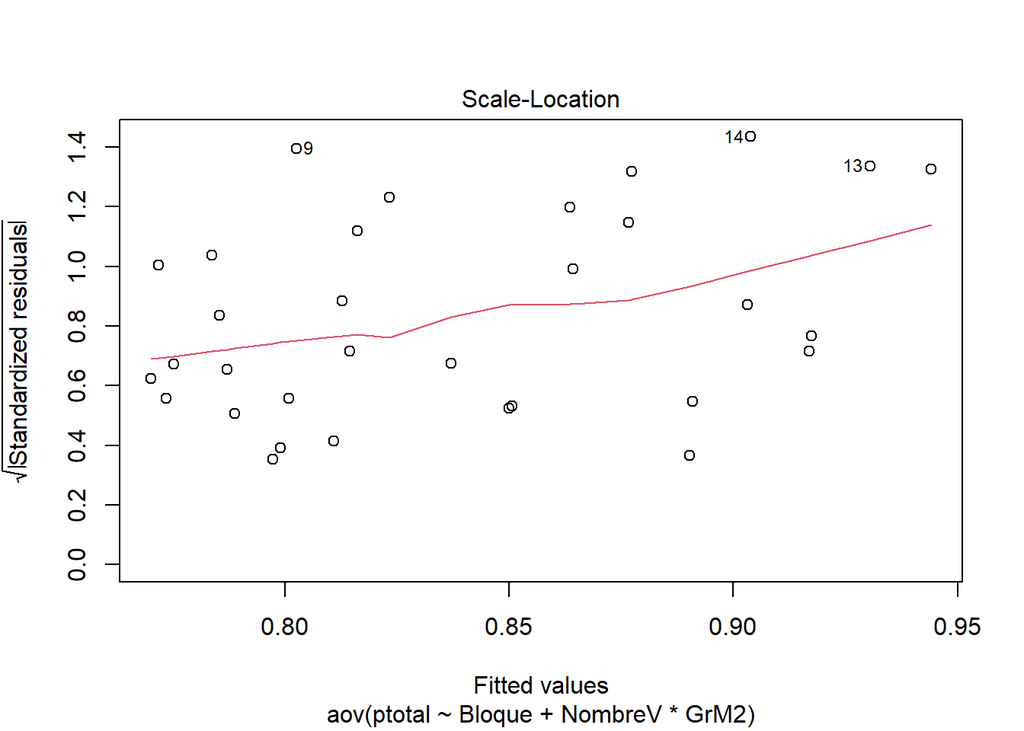

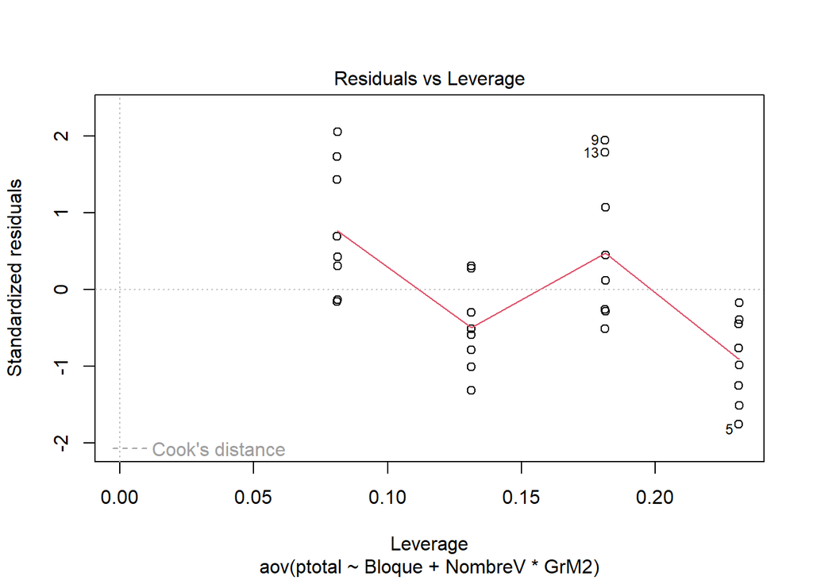

```r
 plot(aov(ptotal~Bloque+NombreV*GrM2, MS06DIC))
```

De acuerdo el grafico de residuos normales son outliers el 13, el 9 y el 14.

Analisis ANOVA en bloques

```r
 fat2.dbc( MS06DIC$GrM2,
          MS06DIC$NombreV,
          MS06DIC$Bloque,
          MS06DIC$ptotal,
          quali= c(FALSE, TRUE),
          mcomp="tukey",
          fac.names=c("Gramos Abono por m2", "Variedad")
)
```

```
## ------------------------------------------------------------------------
## Legenda:
## FATOR 1:  Gramos Abono por m2
## FATOR 2:  Variedad
## ------------------------------------------------------------------------
##
##
## Quadro da analise de variancia
## ------------------------------------------------------------------------
##                              GL     SQ QM      Fc   Pr>Fc
## Bloco                         3 3.0320  6 10.4592 0.00020
## Gramos Abono por m2           3 0.2000  3  0.6899 0.56836
## Variedad                      1 0.0657  2  0.6799 0.41887
## Gramos Abono por m2*Variedad  3 0.7135  5  2.4611 0.09082
## Residuo                      21 2.0292  4
## Total                        31 6.0404  1
## ------------------------------------------------------------------------
## CV = 37.08 %
##
## ------------------------------------------------------------------------
## Teste de normalidade dos residuos (Shapiro-Wilk)
## valor-p:  0.3434104
## De acordo com o teste de Shapiro-Wilk a 5% de significancia, os residuos podem ser considerados normais.
## ------------------------------------------------------------------------
##
## Interacao nao significativa: analisando os efeitos simples
## ------------------------------------------------------------------------
## Gramos Abono por m2
## De acordo com o teste F, as medias desse fator sao estatisticamente iguais.
##
## ------------------------------------------------------------------------
##   Niveis  Medias
## 1      0 0.80000
## 2   1282 0.73250
## 3    427 0.88000
## 4    854 0.94125
## ------------------------------------------------------------------------
## Variedad
## De acordo com o teste F, as medias desse fator sao estatisticamente iguais.
## ------------------------------------------------------------------------
##        Niveis   Medias
## 1 Penca Ancha 0.793125
## 2 Penca Verde 0.883750
## ------------------------------------------------------------------------
```

### Area Foliar

realizamos el analisis estadistico descriptivo

```r
descAF06DIC<-resumir2fat(MS06DIC$Dosis, MS06DIC$NombreV, MS06DIC$A, MS06DIC$Tratamientos, MS06DIC)
descAF06DIC
```

| agrupamientos | numero | medias | Desvio_Standar | CV |
| --- | --- | --- | --- | --- |
| 1 | 8 | 158.1707 | 114.35043 | 72.29556 |
| 2 | 8 | 190.8146 | 105.44307 | 55.25943 |
| 3 | 8 | 202.6592 | 118.44347 | 58.44464 |
| 4 | 8 | 152.5006 | 64.97563 | 42.60680 |
| Penca Ancha | 16 | 160.2283 | 72.96300 | 45.53690 |
| Penca Verde | 16 | 191.8443 | 122.11098 | 63.65108 |
| Penca Ancha_1 | 4 | 147.9537 | 118.97332 | 80.41251 |
| Penca Ancha_2 | 4 | 189.3135 | 52.46449 | 27.71302 |
| Penca Ancha_3 | 4 | 124.8955 | 58.57820 | 46.90177 |
| Penca Ancha_4 | 4 | 178.7505 | 53.18485 | 29.75368 |

[output cut: 4 more lines]

Analisis gráfico de la variable

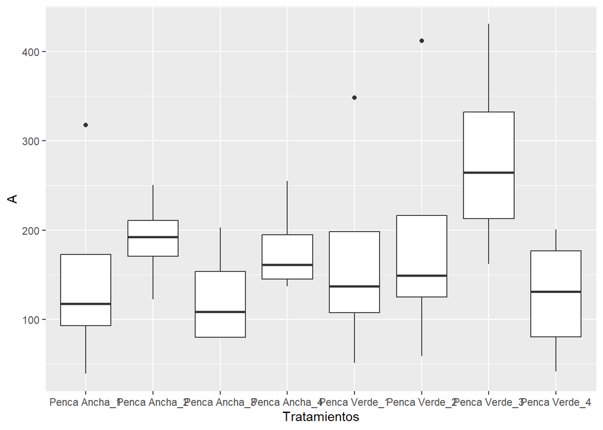

```r
ggplot(data=MS06DIC, aes(Tratamientos, A))+geom_boxplot() ###Un boxplot con todos los tratamientos
```

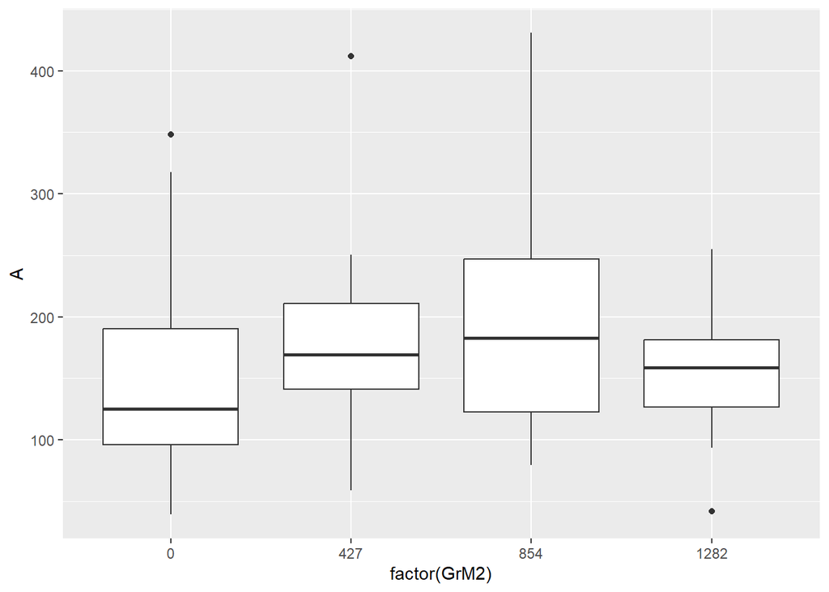

```r
ggplot(data=MS06DIC, aes(factor(GrM2), A))+geom_boxplot() ###Un boxplot considerando solo el factor Abono
```

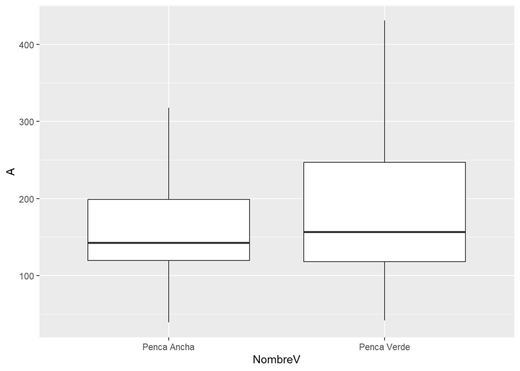

```r
ggplot(data=MS06DIC, aes(NombreV, A))+geom_boxplot() ###Un boxplot considerando solo el factor cultivar
```

Analisis de outlier

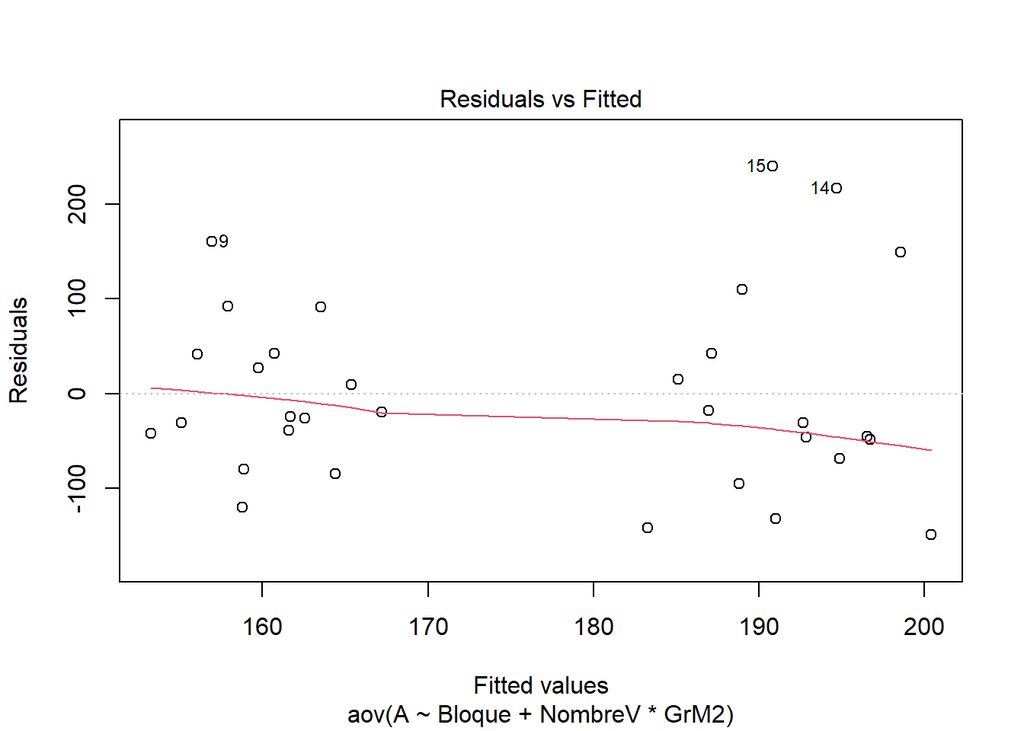

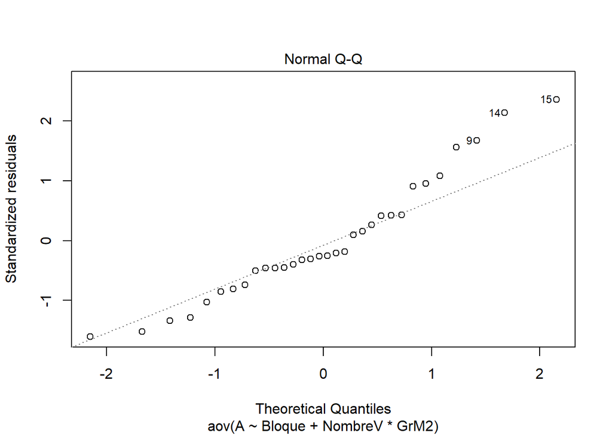

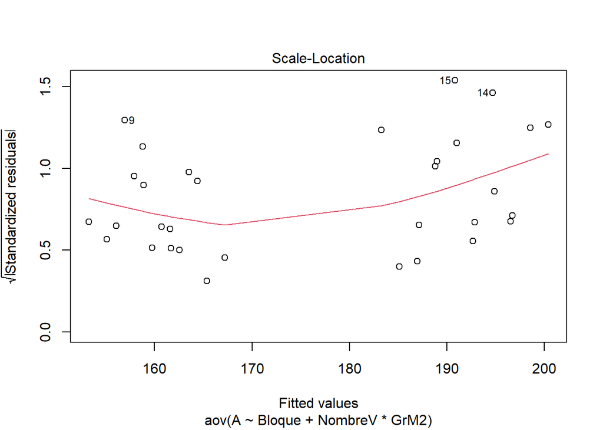

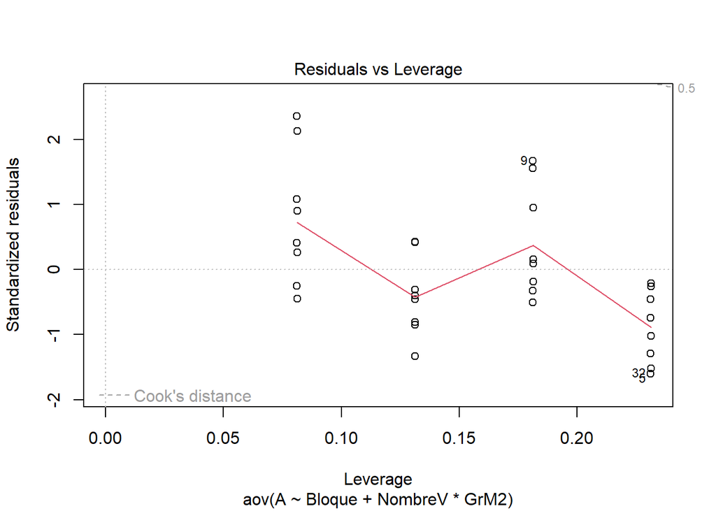

```r
 plot(aov(A~Bloque+NombreV*GrM2, MS06DIC))
```

Analisis ANOVA en bloques

```r
 fat2.dbc( MS06DIC$GrM2,
          MS06DIC$NombreV,
          MS06DIC$Bloque,
          MS06DIC$A,
          quali= c(FALSE, TRUE),
          mcomp="tukey",
          fac.names=c("Gramos Abono por m2", "Variedad")
)
```

```
## ------------------------------------------------------------------------
## Legenda:
## FATOR 1:  Gramos Abono por m2
## FATOR 2:  Variedad
## ------------------------------------------------------------------------
##
##
## Quadro da analise de variancia
## ------------------------------------------------------------------------
##                              GL     SQ QM     Fc   Pr>Fc
## Bloco                         3 141461  3 9.8130 0.00030
## Gramos Abono por m2           3  14402  4 0.9991 0.41269
## Variedad                      1   7997  6 1.6641 0.21107
## Gramos Abono por m2*Variedad  3  46747  2 3.2428 0.04254
## Residuo                      21 100910  5
## Total                        31 311517  1
## ------------------------------------------------------------------------
## CV = 39.38 %
##
## ------------------------------------------------------------------------
## Teste de normalidade dos residuos (Shapiro-Wilk)
## valor-p:  0.4539463
## De acordo com o teste de Shapiro-Wilk a 5% de significancia, os residuos podem ser considerados normais.
## ------------------------------------------------------------------------
##
##
##
## Interacao significativa: desdobrando a interacao
## ------------------------------------------------------------------------
##
## Desdobrando  Gramos Abono por m2  dentro de cada nivel de  Variedad
## ------------------------------------------------------------------------
## ------------------------------------------------------------------------
## Quadro da analise de variancia
## ------------------------------------------------------------------------
##                                          GL         SQ        QM     Fc  Pr.Fc
## Bloco                                     3 141461.420 47153.807  9.813  3e-04
## Variedad                                  1   7996.572  7996.572 1.6641 0.2111
## Gramos Abono por m2:Variedad Penca Ancha  3  10352.368  3450.789 0.7181 0.5522
## Gramos Abono por m2:Variedad Penca Verde  3  50796.528 16932.176 3.5237 0.0327
```

[output cut: 141 more lines]

```
## ------------------------------------------------------------------------
## Grupos Tratamentos Medias
## a     Penca Verde     280.423
##  b    Penca Ancha     124.8955
## ------------------------------------------------------------------------
##
##
##  Variedad  dentro do nivel  1282  de  Gramos Abono por m2
##
## De acordo com o teste F, as medias desse fator sao estatisticamente iguais.
## ------------------------------------------------------------------------
##        Niveis   Medias
## 1 Penca Ancha 178.7505
## 2 Penca Verde 126.2507
## ------------------------------------------------------------------------
```

### Relacion raiz Parte Aerea

Creamos la variable

```r
MS06DIC$Rpa<-MS06DIC$Peso_Raiz/MS06DIC$Pesos_hojas
```

realizamos el analisis estadistico descriptivo

```r
descRA06DIC<-resumir2fat(MS06DIC$Dosis, MS06DIC$NombreV, MS06DIC$Rpa, MS06DIC$Tratamientos, MS06DIC)
descRA06DIC
```

| agrupamientos | numero | medias | Desvio_Standar | CV |
| --- | --- | --- | --- | --- |
| 1 | 8 | 0.14775143 | 0.06622615 | 44.82268 |
| 2 | 8 | 0.10745707 | 0.03963840 | 36.88766 |
| 3 | 8 | 0.10620938 | 0.03514508 | 33.09037 |
| 4 | 8 | 0.09504278 | 0.02058253 | 21.65607 |
| Penca Ancha | 16 | 0.11731001 | 0.04822313 | 41.10743 |
| Penca Verde | 16 | 0.11092032 | 0.04540094 | 40.93112 |
| Penca Ancha_1 | 4 | 0.15395196 | 0.06466032 | 42.00032 |
| Penca Ancha_2 | 4 | 0.10662241 | 0.04666102 | 43.76286 |
| Penca Ancha_3 | 4 | 0.12729701 | 0.03316873 | 26.05618 |
| Penca Ancha_4 | 4 | 0.08136866 | 0.01926497 | 23.67615 |

[output cut: 4 more lines]

Analisis gráfico de la variable

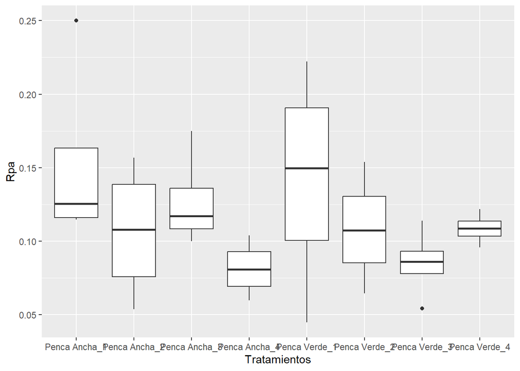

```r
ggplot(data=MS06DIC, aes(Tratamientos, Rpa))+geom_boxplot() ###Un boxplot con todos los tratamientos
```

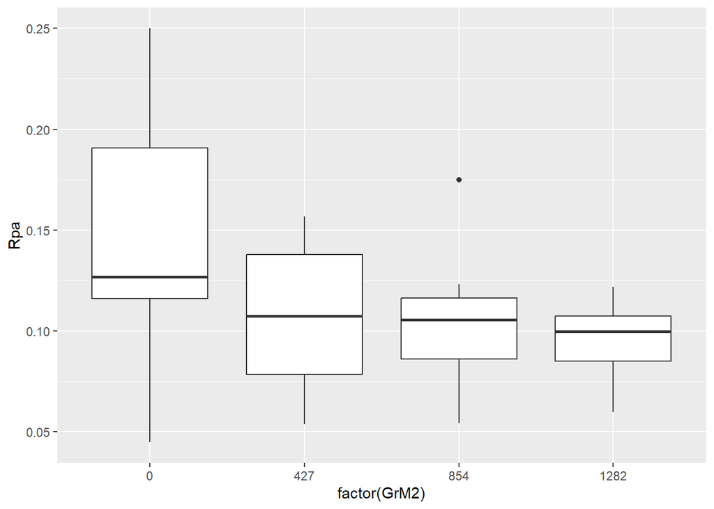

```r
ggplot(data=MS06DIC, aes(factor(GrM2), Rpa))+geom_boxplot() ###Un boxplot considerando solo el factor Abono
```